# Part3 Python的可视化技巧梳理

### 属性两两之间关系的可视化

这个应该是seaborn最吸引人的地方之一了，非常方便地把多个features中每两个features做一次散点图（包括自己和自己比较），以探求其关系。所以，如果是4个属性的话，就会有16张子图。

```
   sepal_length  sepal_width  petal_length  petal_width species
0           5.1          3.5           1.4          0.2  setosa
1           4.9          3.0           1.4          0.2  setosa
```

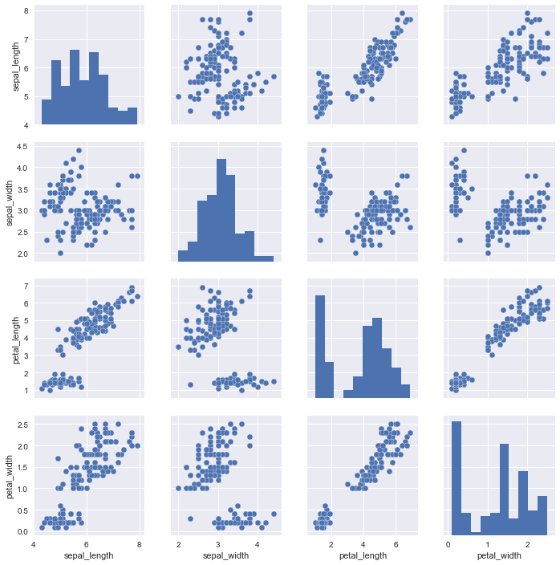

```python
import numpy as np
import pandas as pd
import seaborn as sns
import matplotlib.pyplot as plt
from scipy import stats, integrate
%matplotlib inline
sns.set(color_codes=True)
iris = sns.load_dataset("iris")
sns.pairplot(iris)#对角线是直方图(统计数量)，其他的是散点图
print(iris.head(2))
plt.show()
```

### 回归分析

regplot()和lmplot()都可以绘制回归关系,但推荐regplot()

regplot()和lmplot()都可以绘制线性回归曲线。这两个函数非常相似，甚至共有一些核心功能。我将着力讲解二者的区别，这会帮助你选用恰当的工具。

在最简单的调用中，两个函数都会画出双变量的散点图，然后以y~x拟合回归方程和预测值95%置信区间并将其画出。

两者间主要的区别是，regplot接受各种格式的x y，包括numpy arrays ,pandas series 或者pandas Dataframe对象。相比之下,lmplot()只接受字符串对象。这种数据格式被称为’long-form’或者’tidy’。

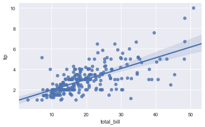

```python
#最普通的一元回归
tips = sns.load_dataset("tips")
sns.regplot(x="total_bill", y="tip", data=tips)
plt.show()
```

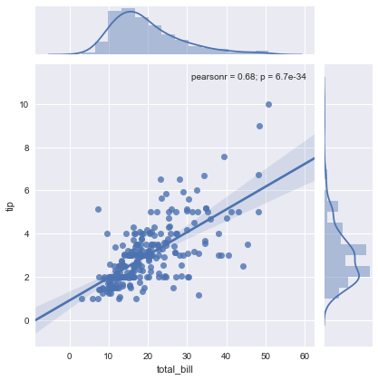

```python
#jointplot()可以通过传递kind =”reg”来显示关键子图的线性回归拟合
sns.jointplot(x="total_bill", y="tip", data=tips, kind="reg")
plt.show()
```

### 多变量的分类可视化

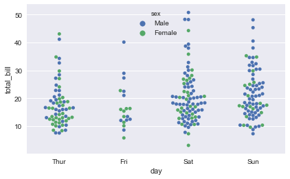

```python
#树形图
tips = sns.load_dataset("tips")
sns.swarmplot(x="day", y="total_bill",hue="sex",data=tips)
plt.show()
```

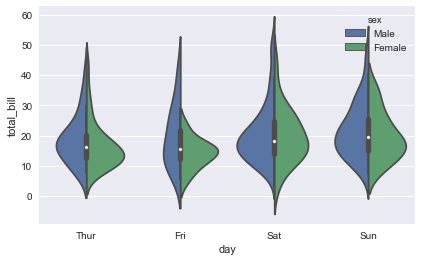

```python
#小提琴图
sns.violinplot(x="day", y="total_bill", hue="sex", data=tips, split=True)#hue是用来分类的，去掉hue="sex" 和split=True, 不影响图的形状，只是没有分类而已
plt.show()
```

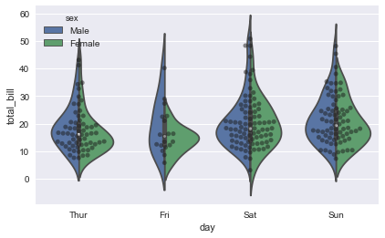

```python
#两者进行结合
sns.violinplot(x="day", y="total_bill",hue="sex", data=tips, split=True )
sns.swarmplot(x="day", y="total_bill", data=tips, color="k", alpha=.5)
plt.show()
```

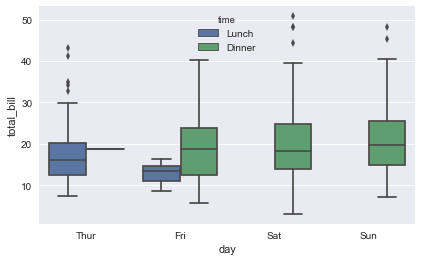

```python
#盒图
sns.boxplot(x="day", y="total_bill", hue="time", data=tips)
plt.show()
```

### 热度图

类似于三维热力图，有xy两个属性的自变量，纵坐标的高度是我们关心的因变量。因变量的大小在三维图中反映为高度，在热力图中反映为颜色的深浅。

```
month  January  February  March  April  May  June  July  August  September  \
year
1949       112       118    132    129  121   135   148     148        136

month  October  November  December
year
1949       119       104       118
```

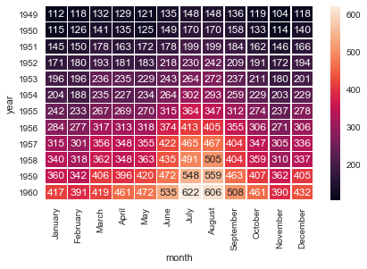

```python
flights = sns.load_dataset("flights")
flights = flights.pivot( "year","month", "passengers")#创建透视图，第一个参数为纵坐标，第二个参数为横坐标，第三个参数为值
print (flights.head(1))
ax = sns.heatmap(flights, annot=True,fmt="d",linewidths=.5)
```